# R Notebook

```r
library(survival)
# library(condSURV)
# library(JM)
# library(dplyr)
# library(survminer)
# library(clustcurv)
library(psych)
library(ggplot2)
```

This downloads the data, and edits it a bit. In partifcular loan status is transformed, variables are turned into dates, the year 2006 is selected etc. This is from an online course on survival data.

```r
web <- "https://s3.amazonaws.com/udacity-hosted-downloads/ud651/prosperLoanData.csv"
loan <- read.csv(web)

# Remove duplicates by LoanKey
loan_nd <- loan[!duplicated(loan$LoanKey), ]

# removing LoanStatus no needed
sel_status  <- loan_nd$LoanStatus %in% c("Completed", "Current",
                                         "ChargedOff", "Defaulted",
                                         "Cancelled")
loan_filtered <- loan_nd[sel_status, ]

# creating status variable for censoring
loan_filtered$status <- ifelse(
  loan_filtered$LoanStatus == "Defaulted" |
    loan_filtered$LoanStatus == "Chargedoff",  1, 0)

# adding the final date to "current" status
head(levels(loan_filtered$ClosedDate))
```

```r
## [1] ""                    "2005-11-25 00:00:00" "2005-11-29 00:00:00"
## [4] "2005-11-30 00:00:00" "2005-12-08 00:00:00" "2005-12-28 00:00:00"
levels(loan_filtered$ClosedDate)[1] <- "2014-11-03 00:00:00"

# creating the time-to-event variable
loan_filtered$start <- as.Date(loan_filtered$LoanOriginationDate)
loan_filtered$end <- as.Date(loan_filtered$ClosedDate)
loan_filtered$time <- as.numeric(difftime(loan_filtered$end, loan_filtered$start, units = "days"))

# there is an error in the data (time to event less than 0)
loan_filtered <- loan_filtered[-loan_filtered$time < 0, ]

# just considering a year of loans creation
ii <- format(as.Date(loan_filtered$LoanOriginationDate),'%Y') %in% c("2006")
loan_filtered <- loan_filtered[ii, ]

loan_filtered$LA <-  loan_filtered$LoanOriginalAmount/10000


loan_data_2006_cleaned <- loan_filtered
write.csv(to_save_data, 'loan_data_2006_cleaned')
```

```r
describe(loan_data_2006)
```

[output not shown]

|  | vars | n | mean | sd | median | trimmed | mad | min | max | range | skew | kurtosis | se |
| --- | --- | --- | --- | --- | --- | --- | --- | --- | --- | --- | --- | --- | --- |
| ListingKey* | 1 | 4954 | 2477.50 | 1430.24 | 2477.50 | 2477.50 | 1836.20 | 1.00 | 4954.00 | 4953.00 | 0.00 | -1.20 | 20.32 |
| ListingNumber | 2 | 4954 | 36129.75 | 21821.16 | 33394.50 | 35713.30 | 24459.93 | 60.00 | 78611.00 | 78551.00 | 0.20 | -1.04 | 310.03 |
| ListingCreationDate* | 3 | 4954 | 2477.50 | 1430.24 | 2477.50 | 2477.50 | 1836.20 | 1.00 | 4954.00 | 4953.00 | 0.00 | -1.20 | 20.32 |
| CreditGrade* | 4 | 4954 | 4.60 | 1.94 | 5.00 | 4.71 | 1.48 | 1.00 | 8.00 | 7.00 | -0.34 | -0.98 | 0.03 |
| Term | 5 | 4954 | 36.00 | 0.00 | 36.00 | 36.00 | 0.00 | 36.00 | 36.00 | 0.00 | NaN | NaN | 0.00 |
| LoanStatus* | 6 | 4954 | 2.28 | 0.45 | 2.00 | 2.22 | 0.00 | 1.00 | 3.00 | 2.00 | 0.97 | -0.97 | 0.01 |
| ClosedDate* | 7 | 4954 | 616.15 | 337.87 | 574.00 | 617.03 | 467.02 | 1.00 | 1156.00 | 1155.00 | 0.04 | -1.41 | 4.80 |
| BorrowerAPR | 8 | 4951 | 0.20 | 0.07 | 0.19 | 0.19 | 0.09 | 0.01 | 0.51 | 0.51 | 0.14 | -0.77 | 0.00 |
| BorrowerRate | 9 | 4954 | 0.19 | 0.07 | 0.18 | 0.19 | 0.09 | 0.00 | 0.50 | 0.50 | 0.14 | -0.75 | 0.00 |
| LenderYield | 10 | 4954 | 0.18 | 0.07 | 0.17 | 0.18 | 0.09 | 0.00 | 0.49 | 0.50 | 0.17 | -0.70 | 0.00 |

[output cut: 76 more lines]

I did not really analyse the entire dataset much. You’d have to filter it quite carefully. Many NA’s are present. Also many ’ ’ empty strings are present.

```r
print(sum(!complete.cases(loan_data_2006[,"BorrowerState"])))
```

[output not shown]

```r
# print(colSums(is.na(loan_data_2006)))
loan_data_2006 = loan_data_2006_cleaned[, colSums(is.na(loan_data_2006_cleaned)) == 0]
# loan_data_2006 = loan_data_2006[, colSums(is.na(loan_data_2006)) == 0]
print(colSums(loan_data_2006 == '') == 0)
```

```
                     ListingKey                   ListingNumber             ListingCreationDate
                           TRUE                            TRUE                            TRUE
                    CreditGrade                            Term                      LoanStatus
                           TRUE                            TRUE                            TRUE
                     ClosedDate                    BorrowerRate                     LenderYield
                           TRUE                            TRUE                            TRUE
          ProsperRating..Alpha.       ListingCategory..numeric.                   BorrowerState
                          FALSE                            TRUE                           FALSE
                     Occupation                EmploymentStatus             IsBorrowerHomeowner
                          FALSE                           FALSE                            TRUE
               CurrentlyInGroup                        GroupKey                DateCreditPulled
                           TRUE                           FALSE                            TRUE
        FirstRecordedCreditLine           OpenRevolvingAccounts     OpenRevolvingMonthlyPayment
                          FALSE                            TRUE                            TRUE
                    IncomeRange                IncomeVerifiable             StatedMonthlyIncome
                           TRUE                            TRUE                            TRUE
                        LoanKey       LoanCurrentDaysDelinquent      LoanMonthsSinceOrigination
                           TRUE                            TRUE                            TRUE
                     LoanNumber              LoanOriginalAmount             LoanOriginationDate
                           TRUE                            TRUE                            TRUE
         LoanOriginationQuarter                       MemberKey              MonthlyLoanPayment
                           TRUE                            TRUE                            TRUE
            LP_CustomerPayments    LP_CustomerPrincipalPayments              LP_InterestandFees
                           TRUE                            TRUE                            TRUE
                 LP_ServiceFees               LP_CollectionFees           LP_GrossPrincipalLoss
                           TRUE                            TRUE                            TRUE
            LP_NetPrincipalLoss LP_NonPrincipalRecoverypayments                   PercentFunded
                           TRUE                            TRUE                            TRUE
                Recommendations      InvestmentFromFriendsCount     InvestmentFromFriendsAmount
                           TRUE                            TRUE                            TRUE
                      Investors                          status                           start
                           TRUE                            TRUE                              NA
                            end                            time             LoanOriginalAmount2
                             NA                            TRUE                            TRUE
```

Select the subset of the data:

```r
subset_data = loan_data_2006[, c("IsBorrowerHomeowner", "LoanOriginalAmount2", 'time', 'status')]
```

Fit a cox model without including spline terms on all data (4954 loans, of which 1373 are observed events. I.e. 28 % of the events is observed.). This results in significant effect. Overall p-value is p=4.358e-06.

```r
mfit <- coxph(Surv(time, status) ~ IsBorrowerHomeowner + LoanOriginalAmount2, data=subset_data)
mfit
```

```
Call:
coxph(formula = Surv(time, status) ~ IsBorrowerHomeowner + LoanOriginalAmount2,
    data = subset_data)

                            coef exp(coef) se(coef)      z        p
IsBorrowerHomeownerTrue -0.24926   0.77938  0.06210 -4.014 5.97e-05
LoanOriginalAmount2     -0.13293   0.87553  0.06649 -1.999   0.0456

Likelihood ratio test=24.69  on 2 df, p=4.358e-06
n= 4954, number of events= 1373
```

Now we fit again a model on all the data, but we include spline terms for the LoanOriginalAmount2. With a spline of order 3 the overall p-value is p=9e-09. The plot seems to suggest medium sized loans have the least risk to default.

```r
mfit <- coxph(Surv(time, status) ~ IsBorrowerHomeowner + pspline(LoanOriginalAmount2,3) , data=subset_data)
mfit
```

```
Call:
coxph(formula = Surv(time, status) ~ IsBorrowerHomeowner + pspline(LoanOriginalAmount2,
    3), data = subset_data)

                             coef se(coef)     se2   Chisq   DF       p
IsBorrowerHomeownerTrue   -0.2378   0.0623  0.0623 14.5902 1.00 0.00013
pspline(LoanOriginalAmoun -0.1072   0.0614  0.0609  3.0474 1.00 0.08087
pspline(LoanOriginalAmoun                          17.5656 2.09 0.00017

Iterations: 6 outer, 14 Newton-Raphson
     Theta= 0.979
Degrees of freedom for terms= 1.0 3.1
Likelihood ratio test=43.5  on 4.09 df, p=9e-09
n= 4954, number of events= 1373
```

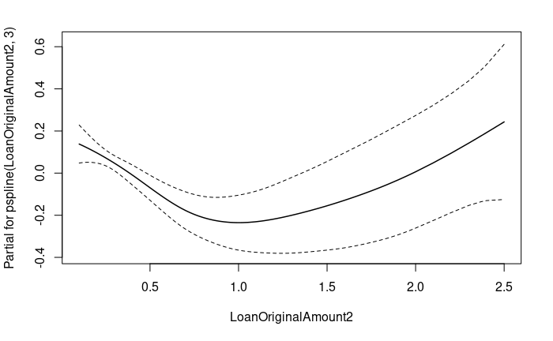

```r
termplot(mfit, term=2, se=TRUE, col.term=1, col.se=1)
```

```r
ptemp <- termplot(mfit, se=TRUE, plot=FALSE)
```

We now plot the two KM curves for the binary variable IsBorrowerHomeowner. Actually the CPH assumption seems quite fine, except for a couple of observations at the end.

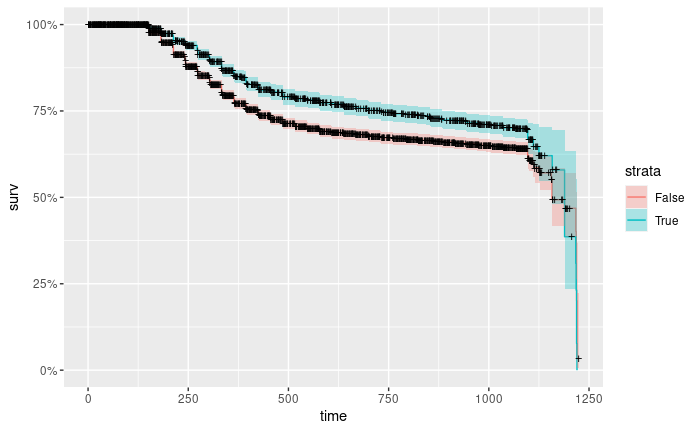

```r
km_trt_fit <- survfit(Surv(time, status) ~ IsBorrowerHomeowner, data=subset_data)
autoplot(km_trt_fit)
```

Now we do the analysis for smaller sample sizes:

```r
mfit <- coxph(Surv(time, status) ~ IsBorrowerHomeowner + LoanOriginalAmount2 , data=subset_data[sample(nrow(subset_data), 1000),])
mfit
```

```
Call:
coxph(formula = Surv(time, status) ~ IsBorrowerHomeowner + LoanOriginalAmount2,
    data = subset_data[sample(nrow(subset_data), 1000), ])

                            coef exp(coef) se(coef)      z     p
IsBorrowerHomeownerTrue -0.13755   0.87149  0.13401 -1.026 0.305
LoanOriginalAmount2      0.04402   1.04501  0.13482  0.327 0.744

Likelihood ratio test=1.11  on 2 df, p=0.5735
n= 1000, number of events= 270
```